# Homework 3 assignment

fc2440

October 18, 2014

A. Identify two surveys to compare

Use World Values Survey 2005 and General Social Survey 2012 and look at the question about happiness as well as income.

In terms of happiness, the survey question in World Values Survey 2005 states: Describe your feeling of happiness; while the survey question in General Social Survey 2012 states: How happy you are?

In terms of income, the survey question in World Values Survey 2005 asks for the scale of income; while the survey question in General Social Survey 2012 asks for real family income.

B. Sketch and/or describe the graph(s)

The graph I intend to make is how happiness is associated with income, which should be positive correlation according to my hypothesis.

C. Write down the target shape

I will be using only two variables from each survey: “realinc” and “happy7” in General Social Survey as well as “v10” (happiness) and “v253” (income) in World Value Survey.

D. Write a script that reads, transforms, prepares data

```r
wvs_data <- read.csv("/Users/Chen/Desktop/Data Visualization/hw3/WVS2005.csv", header=T)
gss_data <- read.csv("/Users/Chen/Desktop/Data Visualization/hw3/GSS2012.csv", header=T)
```

E. Make graphs

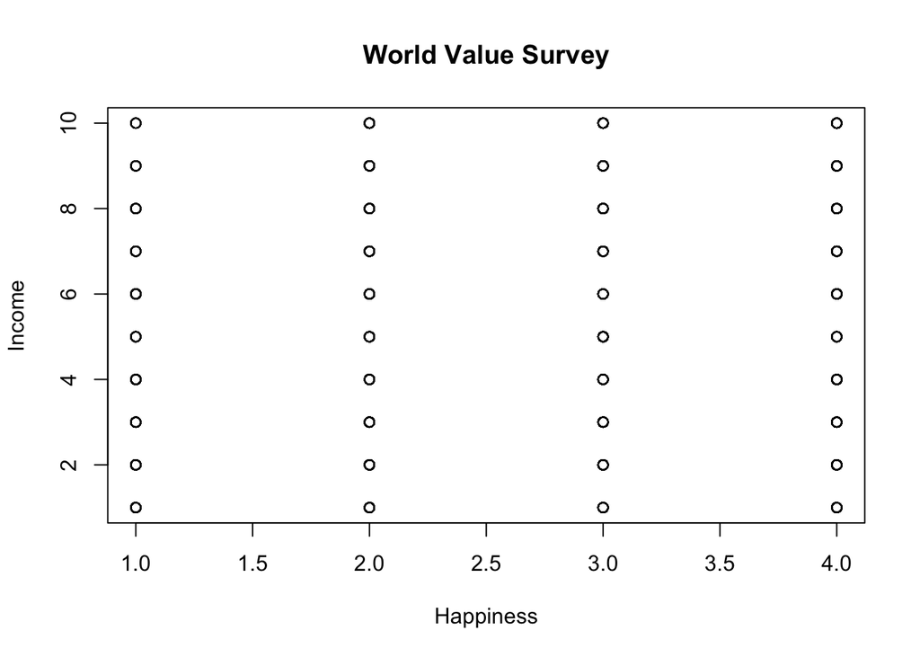

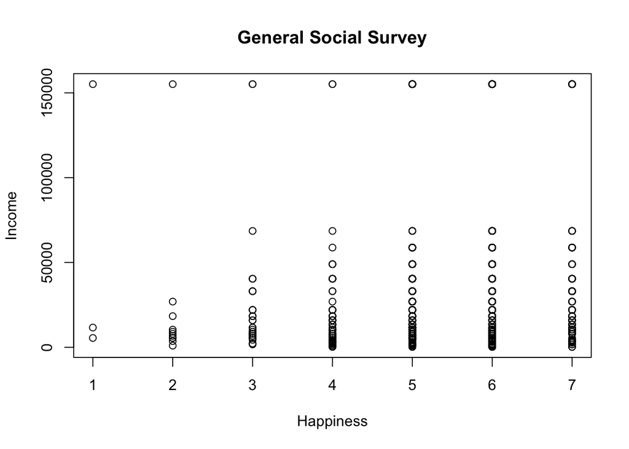

F. Write expressive fantasy function calls

```r
wvs_data <- read.csv("/Users/Chen/Desktop/Data Visualization/hw3/WVS2005.csv", header=T) #read World Value Survey data
gss_data <- read.csv("/Users/Chen/Desktop/Data Visualization/hw3/GSS2012.csv", header=T) #read General Social Survey data
plot(wvs_data$happy,wvs_data$income, main="World Value Survey", xlab="Happiness",ylab="Income") #plot World Value Survey data
plot(gss_data$happy,gss_data$income, main="General Social Survey", xlab="Happiness",ylab="Income") #plot General Social Survey data
```